# Exam

Lucas Vicentim Perasolo

31/07/2020

#### Dependencies

```r
library(openintro)
library(tidyverse)
library(GGally)
library(infer)
library(ggplot2)
library(ggfortify)
```

#### Sheet 2: Read Data, Mean & Median Analysis, Boxplot and Association between Variables

```r
acs12 %>%
  group_by(race) %>%
    summarise(sample_mean = mean(time_to_work, na.rm = TRUE),
              sample_median = median(time_to_work, na.rm = TRUE))
```

```
## # A tibble: 4 x 3
##   race  sample_mean sample_median
##   <fct>       <dbl>         <dbl>
## 1 white        25.4            20
## 2 black        29.7            20
## 3 asian        31.5            30
## 4 other        23.8            20
```

Plotting the relationship between a discrete x and continuos y

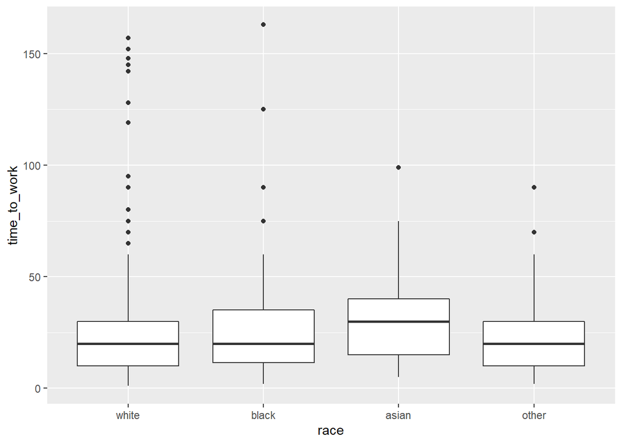

```r
ggplot(acs12, aes(x=race, y=time_to_work)) + geom_boxplot()
```

Plotting the relationship between a continuos y and continuos y

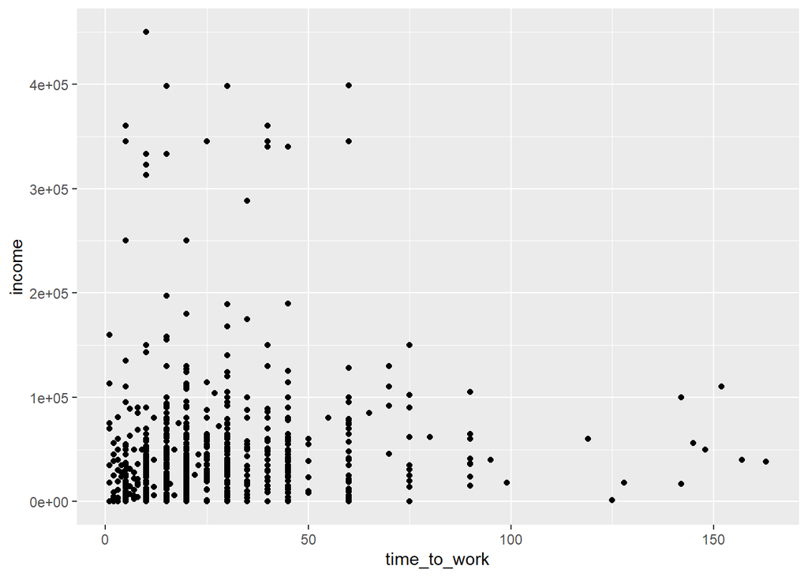

```r
ggplot(acs12, aes(x=time_to_work, y=income)) + geom_point()
```

```r
quantile(acs12$income, .95, na.rm = TRUE)
```

```
##   95%
## 92000
```

Importing data and plotting

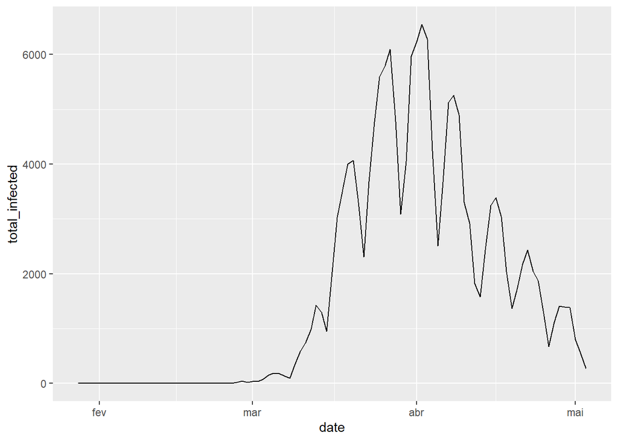

```r
covid_data <- read_csv("covid.csv")

date_total <- covid_data %>%
                group_by(date) %>%
                summarise(total_infected = sum(number_infected, na.rm=TRUE))
ggplot(date_total, aes(x=date, y=total_infected)) + geom_line()
```

Grouping data by a parameter which first must be created becuase it depends on the sum of values from another parameter

```r
federal_average <- covid_data %>%
                    group_by(federal_state) %>%
                    summarise(average_infection = mean(number_infected))
federal_average
```

```
## # A tibble: 16 x 2
##    federal_state          average_infection
##    <chr>                              <dbl>
##  1 Baden-Württemberg                   1.33
##  2 Bayern                              1.38
##  3 Berlin                              1.12
##  4 Brandenburg                         1.13
##  5 Bremen                              1.34
##  6 Hamburg                             1.94
##  7 Hessen                              1.15
##  8 Mecklenburg-Vorpommern              1.08
##  9 Niedersachsen                       1.22
## 10 Nordrhein-Westfalen                 1.27
## 11 Rheinland-Pfalz                     1.15
## 12 Saarland                            1.31
## 13 Sachsen                             1.24
## 14 Sachsen-Anhalt                      1.15
## 15 Schleswig-Holstein                  1.11
## 16 Thüringen                           1.07
```

Analyzing according to a specific filter

```r
bayern <- covid_data %>%
            filter(federal_state == "Bayern") %>%
            group_by(date) %>%
            summarise(total_infected_bayern_date = sum(number_infected, na.rm=TRUE)) %>%
            summarise(mean = mean(total_infected_bayern_date),
                             median = median(total_infected_bayern_date),
                             std = sd(total_infected_bayern_date),
                             max = max(total_infected_bayern_date),
                             total = sum(total_infected_bayern_date), na.rm=TRUE)
```

Contigency table

```r
c_table <- read_csv("covid_too.csv")

dt <- table(c_table$sex, c_table$age_group)
addmargins(dt)
```

```
##
##       A00-A04 A05-A14 A15-A34 A35-A59 A60-A79   A80+    Sum
##   M       763    1782   19474   32524   16274   6658  77475
##   W       657    1673   20666   35734   14706  11613  85049
##   Sum    1420    3455   40140   68258   30980  18271 162524
```

#### Sheet 4: Randomization technique (Checking for independence)

HA : The variables group and survived are not independent. The difference in survival rates between the control and treatment groups was not due to chance and the heart transplant is effective

Preparing

```r
df <- tibble(
transplant = c(rep('treatment', 69), rep('control', 34)),
survived = c(rep(c('yes', 'no'), c(24, 45)),
rep(c('yes', 'no'), c(4, 30)))
)

(treatment_per <- df %>%
filter(transplant == 'treatment', survived == 'yes') %>%
summarise(per_surv = n() / nrow(filter(df, transplant == 'treatment'))))
```

```
## # A tibble: 1 x 1
##   per_surv
##      <dbl>
## 1    0.348
```

```r
(control_per <- df %>%
filter(transplant == 'control', survived == 'yes') %>%
summarise(per_surv = n() / nrow(filter(df, transplant == 'control'))))
```

```
## # A tibble: 1 x 1
##   per_surv
##      <dbl>
## 1    0.118
```

```r
(diff_stat <- treatment_per - control_per)
```

```
##   per_surv
## 1 0.230179
```

Idea: Randomly permute the variable transplant and leave survived as it is. If they are independent, the value of the statistic should be comparable. But we need to repeat those steps several times.

```r
set.seed(12345) # running this command, makes the result reproducible
N <- 100
diff_stat_perm <- vector("numeric", N)
for(i in 1:N){
df_perm <- df %>%
mutate(transplant = sample(transplant, nrow(df)))
df_perm_perc <- df_perm %>%
group_by(transplant, survived) %>%
summarise(n = n()) %>%
mutate(freq = n / sum(n))
diff_stat_perm[i] <- df_perm_perc$freq[4] - df_perm_perc$freq[2]
}
sum(abs(diff_stat_perm) >= diff_stat) / N
```

```
## [1] 0.01
```

This means, that we observed a difference (in absolute value) as least as large as 0.230179028132992 just in 0.01 of the N=100 simulation runs. The data provide convincing evidence for the alternative hypothesis of dependence between the variables transplant and survived. Hence there is convincing evidence to suggest that the transplant program is effective.

#### Sheet 05 Distributions

##### Normal Distribution functions

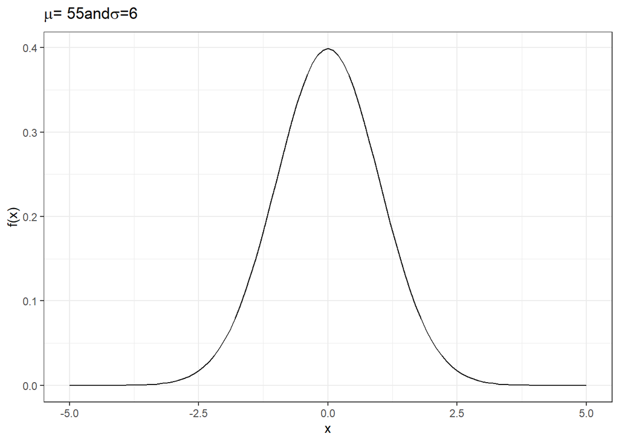

```r
# NORMAL DISTRIBUTION

#dnorm(x, mean = 0, sd = 1, log = FALSE)
#pnorm(q, mean = 0, sd = 1, lower.tail = TRUE, log.p = FALSE) -> Normal probabilities (!)
#qnorm(p, mean = 0, sd = 1, lower.tail = TRUE, log.p = FALSE) -> Quantiles (!)
#rnorm(n, mean = 0, sd = 1)

ggplot(data.frame(x = c(-5, 5)), aes(x)) + stat_function(fun = dnorm) + theme_bw() + ylab("f(x)") + ggtitle(expression(paste(mu,"= 55","and", sigma, "=6")))
```

```r
pert <- pnorm(54, mean=55, sd =6)
pert
```

```
## [1] 0.4338162
```

```r
# BINOMIAL DISTRIBUTION

#dbinom(x, size, prob, log = FALSE)
#pbinom(q, size, prob, lower.tail = TRUE, log.p = FALSE) -> Binomial probability (!)
#qbinom(p, size, prob, lower.tail = TRUE, log.p = FALSE) -> Quantiles (!)
#rbinom(n, size, prob)

# NEGATIVE BINOMIAL DISTRIBUTION

#dnbinom(x, size, prob, mu, log = FALSE)
#pnbinom(q, size, prob, mu, lower.tail = TRUE, log.p = FALSE) -> Negative Binomial probability (!)
#qnbinom(p, size, prob, mu, lower.tail = TRUE, log.p = FALSE) -> Quantiles
#rnbinom(n, size, prob, mu)

# GEOMETRIC DISTRIBUTIONS

#dgeom(x, prob, log = FALSE)
#pgeom(q, prob, lower.tail = TRUE, log.p = FALSE)
#qgeom(p, prob, lower.tail = TRUE, log.p = FALSE)
#rgeom(n, prob)
```

#### Sheet 06 - Intro to Inference (Sampling Analysis)

##### Exercise 6.3

```r
# Importing, getting a summary of population parameters and making boxplots
df <- read_csv("age_first_child.csv")
summary(df$age)
```

```
##    Min. 1st Qu.  Median    Mean 3rd Qu.    Max.
##   12.00   22.00   25.00   25.44   28.00   45.00
```

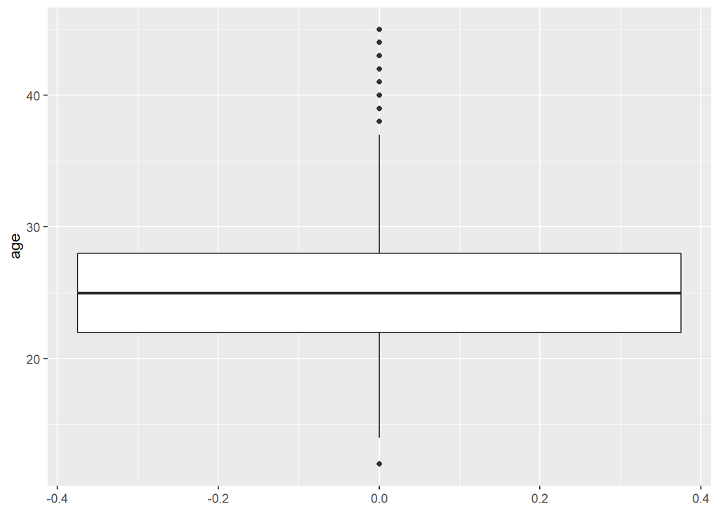

```r
ggplot(df, aes(y = age)) + geom_boxplot()
```

```r
# Point Estimate
pe <- mean(df$age)
pe
```

```
## [1] 25.44019
```

```r
# Bootstrap (1000) resamples
boot_dit <- df %>%
  specify(response = age) %>%
  generate(reps = 1000, type = "bootstrap") %>%
  calculate(stat = "mean")

# Simple Statistics
mean(boot_dit$stat)
```

```
## [1] 25.44131
```

```r
sd(boot_dit$stat)
```

```
## [1] 0.06620195
```

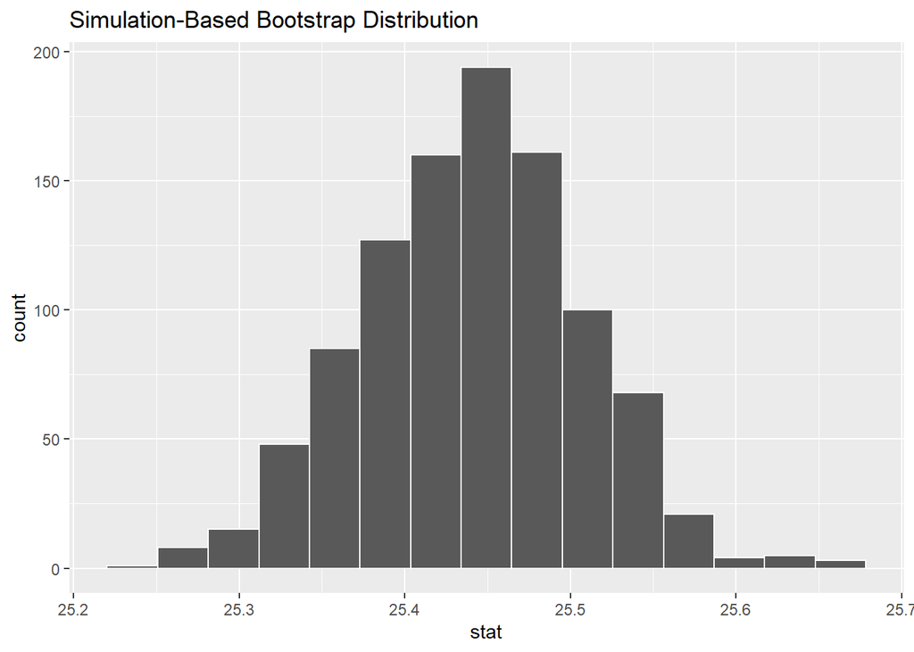

```r
visualise(boot_dit)
```

```r
# Getting Quantiles
q <- quantile(boot_dit$stat, probs = c(0.05, 0.95))
q
```

```
##       5%      95%
## 25.33195 25.54882
```

```r
# Determining length
diff(q)
```

```
##       95%
## 0.2168684
```

##### Exercise 6.3

```r
# Create a sample data
sample_data <- data.frame(expense = c(rep("cover", 443), rep("not cover", 322)))
sample_data
```

[output not shown]

[output cut: 751 more lines]

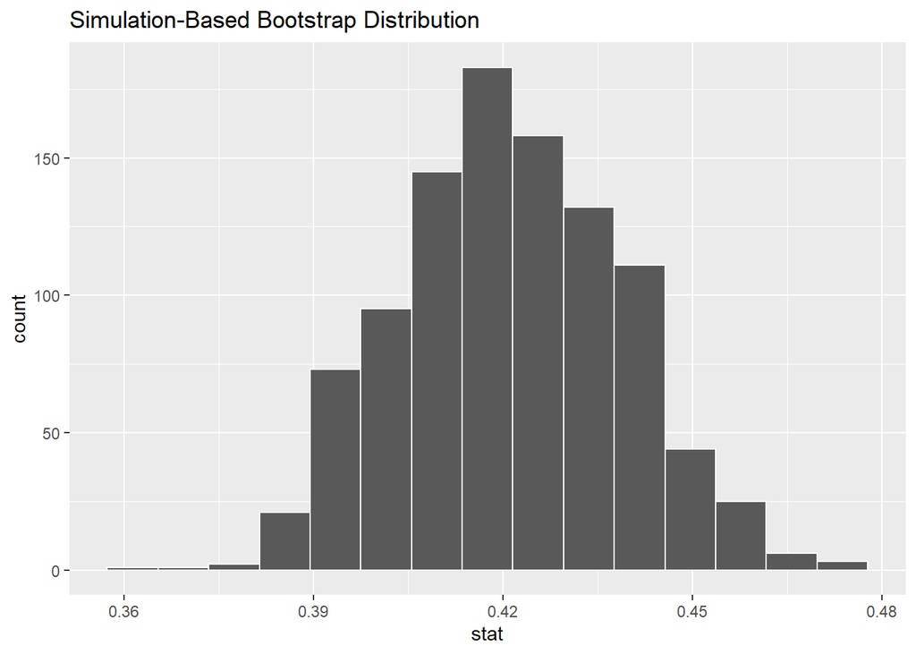

```r
# Bootstrap (1000) resamples
boot_sample_data <- sample_data %>%
                      specify(response = expense, success = "not cover") %>%
                      generate(reps = 1000, type = "bootstrap") %>%
                      calculate(stat = "prop")
visualize(boot_sample_data)
```

```r
# Standard Deviation
sd(boot_sample_data$stat)
```

```
## [1] 0.0173291
```

#### Sheet 07

#### Sheet 08 - Hypothesis testing using Infer & Pvalue command for one and two proportion testing

```r
# Hypothesis
df <- data.frame(status = c(rep("nausea", 7), rep("no nausea", 3)))

null_dist <- df %>%
  specify(response = status, success = "nausea") %>%
  hypothesize(null = "point", p = 0.6) %>%
  generate(reps = 1000) %>%
  calculate(stat = "prop")
```

```r
# Pvalue One Proportion
pnorm(-0.96311, lower.tail = FALSE)
```

```
## [1] 0.8322538
```

```r
# Pvalue two Proportion (!) multiply by 2

pnorm(-0.96311, lower.tail = FALSE) * 2
```

```
## [1] 1.664508
```

```r
tests <- read_csv("test_data.csv")
tests %>%
      group_by(group) %>%
      summarise(mean = mean(EeDbY)) %>%
      slice(1)
```

```
## # A tibble: 1 x 2
##   group  mean
##   <chr> <dbl>
## 1 A     0.137
```

#### Sheet 09

#### Sheet 10

#### Sheet 11

#### Sheet 12

#### Sheet 13

#### Sheet 14